## Chick weights

The `ChickWeight` data set is part of the base package `datasets`. See `?ChickWeight` for details on the data. For all of the questions use `dplyr` functions with the pipe `%>%` whenever possible.

**Submission instructions**: Create a folder named `ds202_hw4`, and name the RMarkDown file including your solutions `hw4.Rmd` under this folder. For the submission, create a GitHub repository named `ds202_hw4` under your GitHub account, and push both `hw4.Rmd` and the knitted `hw4.html` before the deadline. I will assume you use the same GitHub username as for your HW3 submission. The latest version of your homework appearing on GitHub before the deadline is graded. *It is crucial to follow the exact folder structure and file names*. This homework is **due on March 4** before class.

1. Get a frequency breakdown of the number of chicks, their average weight and the standard deviation of the weights in each of the diets at the start of the study. Store the resulting data frame in a variable named `weight0` and print.

```r
library(datasets)
library(dplyr)
```

```r
library(ggplot2)
time0 <- ChickWeight %>% filter(Time==0) %>%
  group_by(Diet)
weight0 <- time0 %>% summarize(number = n(), avg_weight = mean(weight, na.rm = TRUE),
                  standard_dev = sd(weight, na.rm=TRUE))
print(weight0)
```

```
## # A tibble: 4 x 4
##   Diet  number avg_weight standard_dev
##   <fct>  <int>      <dbl>        <dbl>
## 1 1         20       41.4        0.995
## 2 2         10       40.7        1.49
## 3 3         10       40.8        1.03
## 4 4         10       41          1.05
```

2. Each chick should have twelve weight measurements. Use the `dplyr` package to identify how many measurements are there for each chick. Extract a subset of the data for all chicks with complete information, name the data set `complete`, and print the first 3 rows. (Hint: you might want to use mutate to introduce a helper variable consisting of the number of observations)

```r
complete <- ChickWeight %>% group_by(Chick) %>% mutate(Freq = n())
complete <- complete %>% filter(Freq == 12)
head(complete, 3)
```

```
## # A tibble: 3 x 5
## # Groups:   Chick [1]
##   weight  Time Chick Diet   Freq
##    <dbl> <dbl> <ord> <fct> <int>
## 1     42     0 1     1        12
## 2     51     2 1     1        12
## 3     59     4 1     1        12
```

3. In the complete data set introduce a new variable that measures the current weight difference compared to day 0. Name this variable `weightgain` and print the first 3 rows of the new data frame.

```r
complete <- complete %>% mutate(weightgain = weight - weight[Time == 0])
complete
```

```
## # A tibble: 540 x 6
## # Groups:   Chick [45]
##    weight  Time Chick Diet   Freq weightgain
##     <dbl> <dbl> <ord> <fct> <int>      <dbl>
##  1     42     0 1     1        12          0
##  2     51     2 1     1        12          9
##  3     59     4 1     1        12         17
##  4     64     6 1     1        12         22
##  5     76     8 1     1        12         34
##  6     93    10 1     1        12         51
##  7    106    12 1     1        12         64
##  8    125    14 1     1        12         83
##  9    149    16 1     1        12        107
## 10    171    18 1     1        12        129
## # … with 530 more rows
```

4. Use `{ggplot2}` to create side-by-side boxplots of `weightgain` by `Diet` for day 21. Change the order of the categories in the Diet variable such that the boxplots are ordered by median `weightgain`, and the lower limit of the y axis should be 0. Describe the relationship in 2-3 sentences.

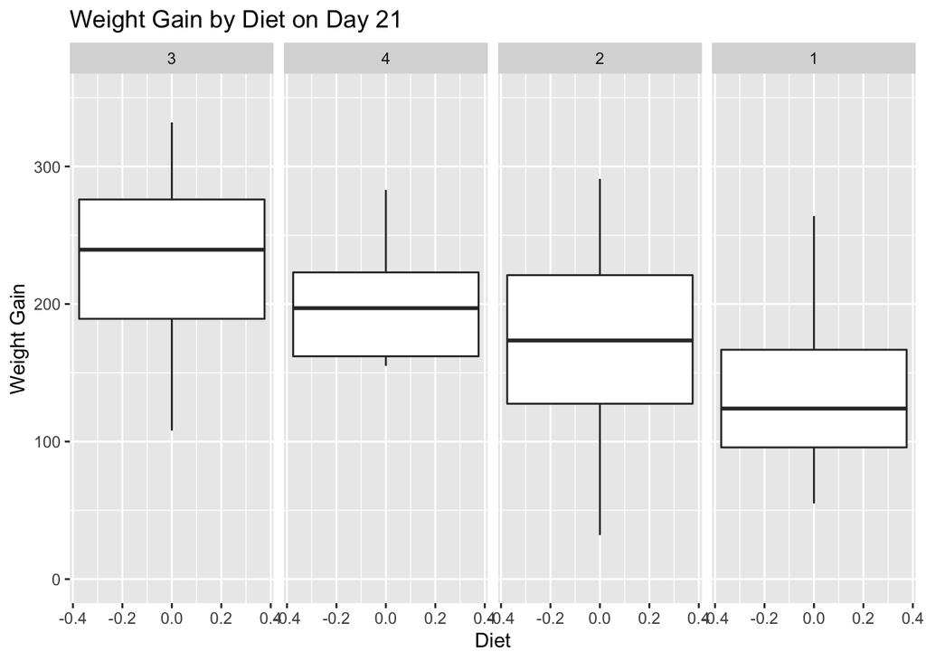

```r
day21 <- complete %>% filter(Time == 21)

day21 %>% mutate(Diet = factor(Diet, levels = c("3", "4", "2", "1")))  %>%
  ggplot(aes(y=weightgain)) + geom_boxplot() + facet_grid(~Diet) +
  ylab("Weight Gain") + xlab("Diet") + ggtitle("Weight Gain by Diet on Day 21") +
  ylim(0, 350)
```

*This relationship shows that Diet 3 appears to be the best diet on Day 21 for weight gain in the chicks. It has the nighest median, and the highest maximum weight gain by a considerate margin. The Q3 value for Diet 3 is also the highest of all the diets by far. It is clear to see that these diets are very different from each other in terms of the weight gain they allow.*

5. Answer each of the following questions using numerical and graphical summary. Also explain what you found: (a) Which chick gained the most weight and which gained the least weight? (b) What diets were they on?

```r
summary(day21$weightgain)
```

```
##    Min. 1st Qu.  Median    Mean 3rd Qu.    Max.
##    32.0   126.0   164.0   177.6   225.0   332.0
```

```r
print(day21 %>% filter(weightgain == 332)) #Chick 35
```

```
## # A tibble: 1 x 6
## # Groups:   Chick [1]
##   weight  Time Chick Diet   Freq weightgain
##    <dbl> <dbl> <ord> <fct> <int>      <dbl>
## 1    373    21 35    3        12        332
```

```r
print(day21 %>% filter(weightgain == 32)) #Chick 24
```

```
## # A tibble: 1 x 6
## # Groups:   Chick [1]
##   weight  Time Chick Diet   Freq weightgain
##    <dbl> <dbl> <ord> <fct> <int>      <dbl>
## 1     74    21 24    2        12         32
```

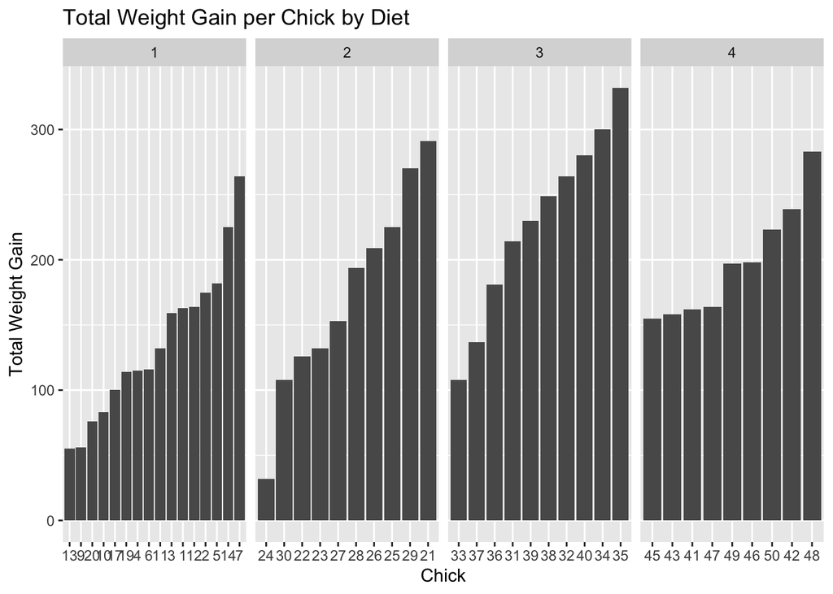

```r
day21 %>%
  ggplot(aes(x=Chick, weight=weightgain)) + geom_bar() + facet_grid(~Diet, scales = "free_x") +
  ggtitle("Total Weight Gain per Chick by Diet") + ylab("Total Weight Gain")
```

6. For the chicks with the least and the most weight at time 0, plot their growth trajectories over time.

```r
summary(complete[complete$Time==0, ])
```

```
##      weight           Time       Chick    Diet        Freq      weightgain
##  Min.   :39.00   Min.   :0   13     : 1   1:16   Min.   :12   Min.   :0
##  1st Qu.:41.00   1st Qu.:0   9      : 1   2:10   1st Qu.:12   1st Qu.:0
##  Median :41.00   Median :0   20     : 1   3:10   Median :12   Median :0
##  Mean   :41.07   Mean   :0   10     : 1   4: 9   Mean   :12   Mean   :0
##  3rd Qu.:42.00   3rd Qu.:0   17     : 1          3rd Qu.:12   3rd Qu.:0
##  Max.   :43.00   Max.   :0   19     : 1          Max.   :12   Max.   :0
##                              (Other):39
```

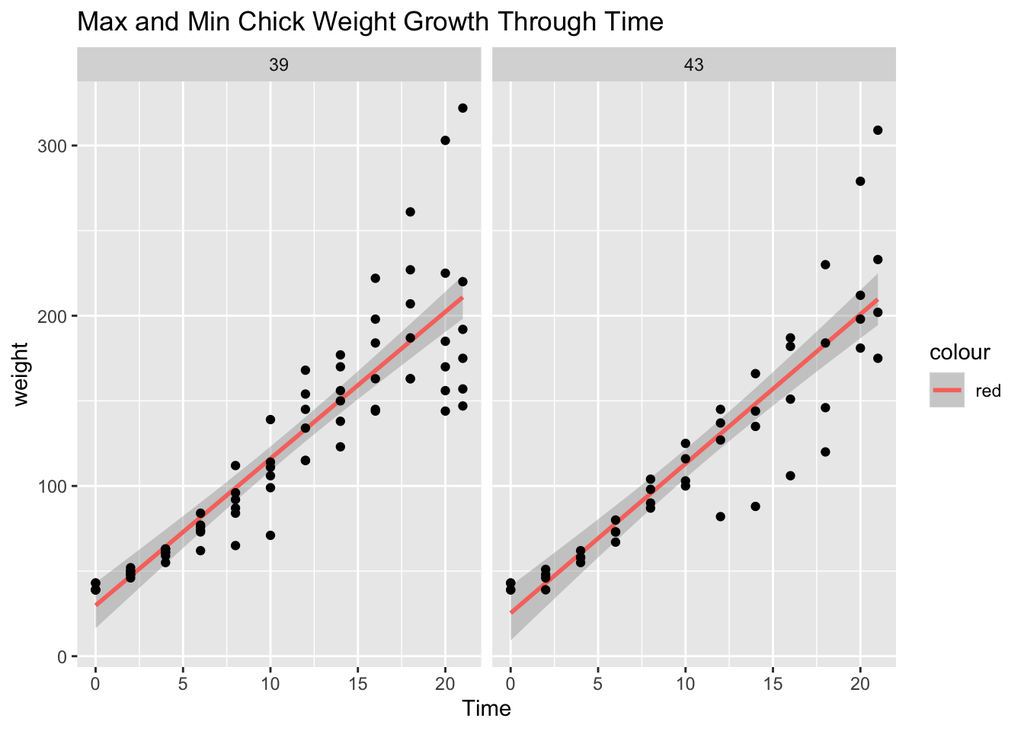

```r
chickMaxMin <- complete %>%
  filter(weight[Time == 0] == 43 | weight[Time == 0] == 39)

number6 <- chickMaxMin %>% ggplot(aes(x=Time, y=weight)) +
  geom_smooth(data = chickMaxMin, aes(x=Time, y=weight, color ='red'), method='lm') +
  facet_wrap(~weight[Time == 0]) + geom_point() + ggtitle("Max and Min Chick Weight Growth Through Time")
number6
```

7. Add to the previous plot the average growth trajectory for all chicks (calculated as the mean weight for each chick at each time). How do the trajectories compare?

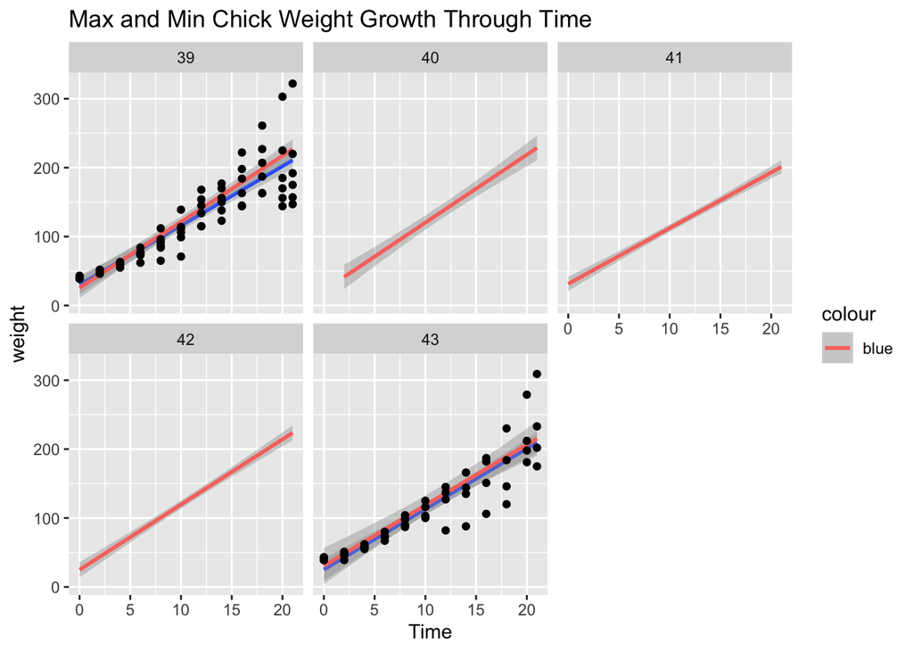

```r
complete %>% filter(weight[Time == 0] == 43 | weight[Time == 0] == 39) %>%
  ggplot(aes(x=Time, y=weight)) + geom_smooth(method='lm') +
  geom_smooth(data = complete, aes(x=Time, y=weight, color ='blue'), method='lm') + geom_point() +
  facet_wrap(~weight[Time == 0]) +
  ggtitle("Max and Min Chick Weight Growth Through Time")
```

*The trajectory shows that the growth of smallest and largest initial weights was right in line with the overall everage trend line per chick. This is not what I expected, as I was expecting these two extremes to be very much different in terms of weight gain.*

8. What else do you find interesting in the dataset? Show your exploratory analysis.

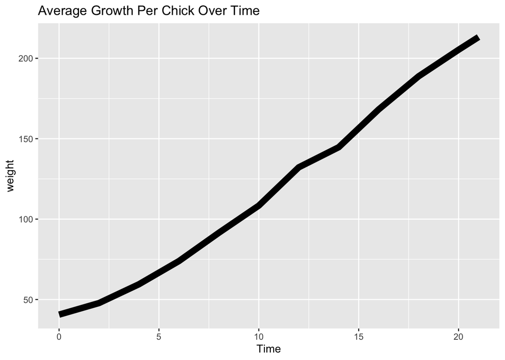

```r
complete %>% filter(weight[Time == 0] == 43 | weight[Time == 0] == 39) %>%
  ggplot(aes(Time, y=weight)) + stat_summary(fun.y=mean, aes(group=1), geom='line', color='black', size = 3) +
  ggtitle("Average Growth Per Chick Over Time")
```

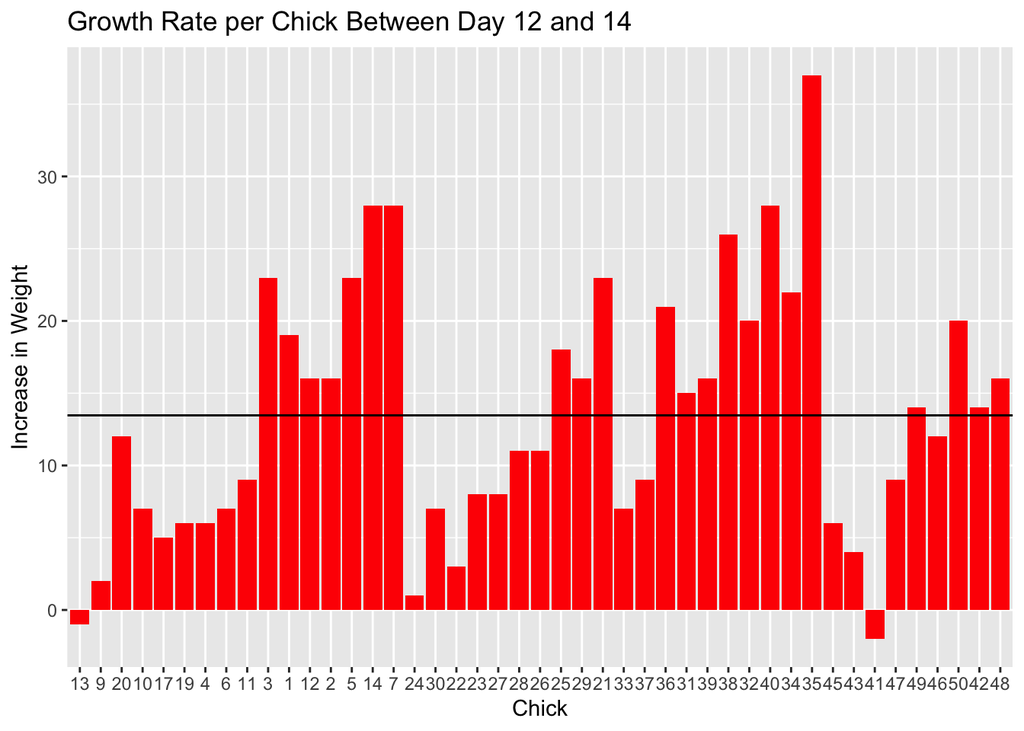

```r
#Create a bar chart showing growth rate per chick between days 10 and 12 and days 12 and 14 to try to see why growth was slow there

day12and14 <- complete %>% filter(Time == 12 | Time == 14) %>%
  mutate(averageGrowthRate = weight[Time == 14] - weight[Time ==12])

day10and12 <- complete %>% filter(Time == 10 | Time == 12) %>%
  mutate(averageGrowthRate = weight[Time == 12] - weight[Time == 10])

weirdDay <- day12and14 %>% filter(Time == 14) %>%
  ggplot(aes(x=Chick, weight=averageGrowthRate)) + geom_bar(fill='red') +
  ggtitle("Growth Rate per Chick Between Day 12 and 14") + ylab("Increase in Weight") +
  geom_hline(aes(yintercept = mean(averageGrowthRate)))

normalDay <- day10and12 %>% filter(Time==12) %>%
  ggplot(aes(x=Chick, weight=averageGrowthRate)) + geom_bar(fill='green') +
  ggtitle("Growth Rate per Chick Between Day 10 and 12") + ylab("Increase in Weight") +
  geom_hline(aes(yintercept = mean(averageGrowthRate)))

weirdDay
```

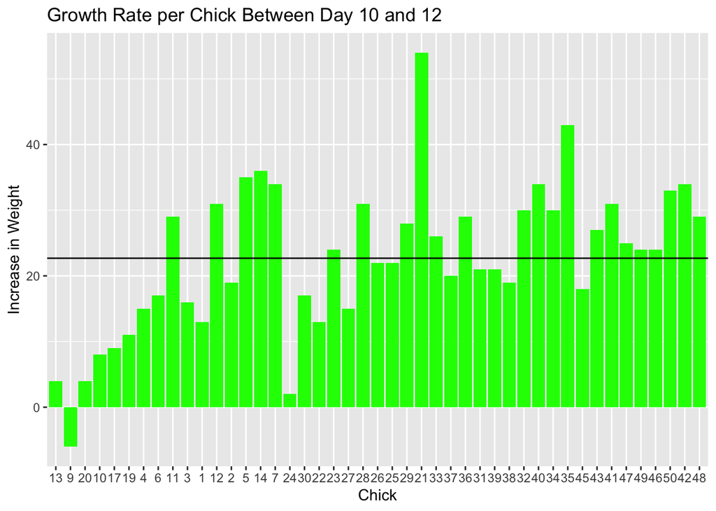

```r
normalDay
```

Note: your submission is supposed to be fully reproducible, i.e. the TA and I will ‘knit’ your submission in RStudio.